# Do I relly have 24 hours in a day: An analysis of how I spend my time

STATS 231: Calendar Query

Lynca Jones Kaminka

Mar 2th, 2023

## Introduction

The Calendar Query Project was our first were the focus were data cleaning ,data analysis and suitable visualizations.

*Questions of interests were:*

1. Does my phone time usage fluctuates throughout the 14 days depending on when I am the most stressed (which is typically Wednesdays and Fridays) and does it increase during the weekends when I don’t have much going on. This is relevant because I believe that I have enough time on my hands to be great at most things I do and one of the things that are holding me back is my inability to manage my time effectively.
2. How the time I spent doing specific activities like studying for classes, going to office hours, doing my personal work and sleeping has changed in the last 14 days compared to each other. It is relevant because I want to understand where I should invest more time.
3. To what extent (in percentage) am I following the weekly schedule that I have established for myself. It can help me become more aware of ways I can adjust how I spend my time. A little caveat, this question had to be revised because when I was extracting the data set from my time-tracking app, I realized that the time when I start and end the activities I was doing was not imported despite being recorded. Thus, I will only be comparing the expected duration and actual direction of my weekly activities).

## Methods

#### **Data collection**

I used 3 raw data sets from: - My Google calendar: it contains how I am plan to spend my days; it is the same from one week to the other. Since the data corresponds to my weekly routine, I manually entered in those activities.I retrieved the data by importing the Google calendar data set into R.

- An app called StayFree: since this is an app that tracks the daily usage time of every app on my smartphone,I didn’t have to actively collect any data except for importing the resulting data set in R.
- An app called Clockify (I used it as a timer). I activated and deactivated a task on it before and after each activity I intended to analyze. As was the case with the other tree data sets, I retrieved the data by importing the data sets. I was unable to import a single data set since the app calculates the time spent doing an activity in a period of time by combining the time I spent doing that activity during that whole time. it would have lost the day-to-day specificity if I had chosen to import the data over a long period of time.

#### **Data wrangling**

##### 1. Data Wrangling for the first visualization:

**Step 1.1** Importing the data sets and basic data cleaning steps The data cleaning steps include filtering out the dates that aren’t in the range of dates I am observing.

**Step 1.2**: Handling missing data: On some days there are activities that I didn’t do, R tends to fill in the empty observation with “N/A”, I am changing it the cells that contain the “N/A” tags into a numeric value: 0.

**Step 1.3** Filtering out the activities that aren’t of interest.

```
## # A tibble: 14 × 7
##      Day `Sleep Duration` `Work shift` `Office Hours` `Personal work` Classes
##    <int>            <int>        <int>          <int>           <int>   <int>
##  1     1            24779         4539              0           10656    5088
##  2     2            25928            0           2315            5733    5245
##  3     3            23756         4620           3499               0    4831
##  4     4            21600         8400           1740               0    5824
##  5     5            27000            0              0           13080       0
##  6     6            25800            0              0               0       0
##  7     7            26278            0              0           17049    6536
##  8     8            24420         4807           6539               0    4955
##  9     9            24300         6840           4500               0   10704
## 10    10            27360         4200           5400            4920    4800
## 11    11            26700         8400           3780               0    6480
## 12    12            21600            0              0            2100       0
## 13    13            25920            0              0               0       0
## 14    14            24101         3600           3219            6672   14105
## # ℹ 1 more variable: `School work` <int>
```

##### 2.Second Data Wrangling: for the data that was recorded by the Screen Time Recorder App.

**Step 2.1**: Importing the data set, getting rid of unneccesary features.

**Step 2.2**: Converting the screen time from a character data type to a numeric data type.

**Step 2.3**: More data cleaning. Extracting the observations of interests by a) renaming columns, ordering the days and arranging the data set in such a way that all apps and their associated usage times can be retrieved and manipulated separately.

**Step 2.4**: Grouping the observations Since I want to compare the times I spent on different app categories, I will have to first isolate the apps that belong to the same category. The categories are social media apps, Youtube and Gmail and all the other apps. Once each app has been grouped under the right category, I can plot the graph that shows the difference of usage between those three different app categories.

**Step 2.5**: Creation of the last dataset which will gather the duration of use of different application categories during the last 14 days

```
## # A tibble: 15 × 4
##      Day `Other Apps` `Social Media Apps` `Youtube&Gmail`
##    <int>        <dbl>               <dbl>           <dbl>
##  1     1         9333                4221            3848
##  2     2        10295                3620            2534
##  3     3        10386                6589            2667
##  4     4        15195                2435            1409
##  5     5         8774                7176            4639
##  6     6         8945                4299            2968
##  7     7         7783                3673            2407
##  8     8         8342                3532            3834
##  9     9        11499                1453            1567
## 10    10        10574                1552            2040
## 11    11         8352                5248            5484
## 12    12         6905                3778            3778
## 13    13        14552                3783            4553
## 14    14        10117                3105            3542
## 15    15         4322                 788            1325
```

##### 3. Data wrangling for the third data set which was imported from my google calendar.

**Step 3.3**: bringing the data sets together

```
## # A tibble: 8 × 4
##   Activities    Duration_Planned Actual_Duration Consistency
##   <chr>                    <dbl>           <dbl>       <dbl>
## 1 bedtime/sleep             7.67            6.94        90.5
## 2 classes                   1.69            1.36        80.5
## 3 clubs                     0.5             0.29        58.8
## 4 office hours              1.21            0.61        50.6
## 5 personal work             1.21            1.19        98.4
## 6 school work               3.55            3.95       111.
## 7 socializing               0.89            0.62        69.7
## 8 work shift                0.86            0.9        105.
```

## Visualizations and Tables

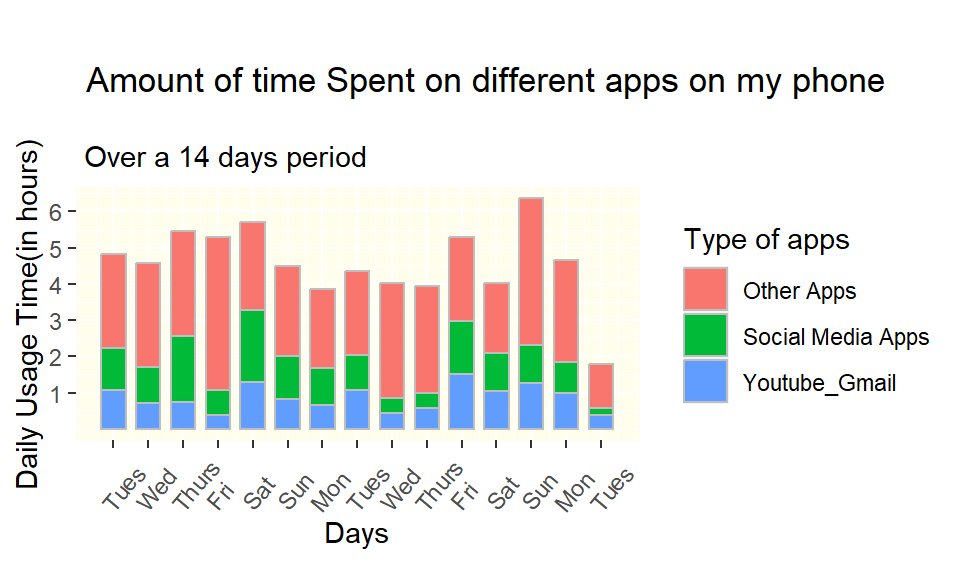

**Visualization 2**: Self-reported time spent on selected activities (represented as a line graph).

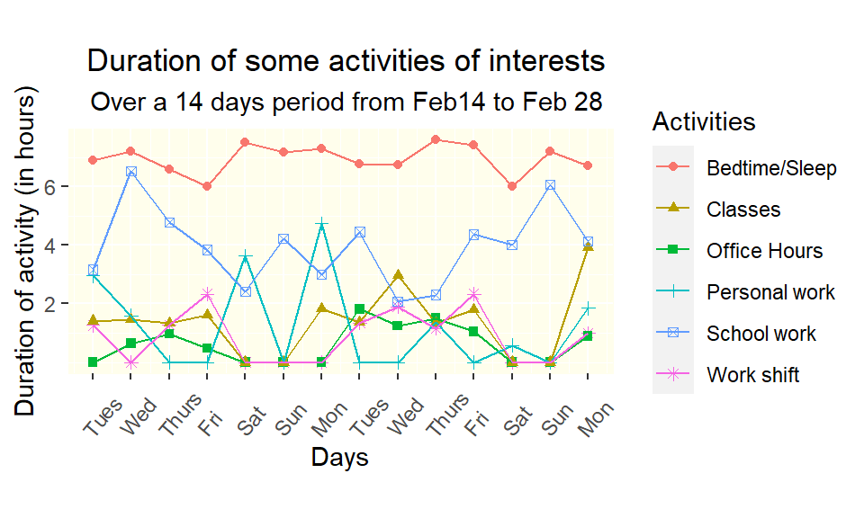

**Visualization 3**: Table that compares with the amount of the length of some of my activities over the last 14 days, and the amount I planned to spend doing those activities.

| Difference between how I plan vs how I actually spend my days Activities | Difference between how I plan vs how I actually spend my days Duration_Planned | Difference between how I plan vs how I actually spend my days Actual_Duration | Difference between how I plan vs how I actually spend my days Consistency |
| --- | --- | --- | --- |
| bedtime/sleep | 7.6666667 | 6.9353571 | 90.46118 |
| classes | 1.6904762 | 1.3604762 | 80.47887 |
| clubs | 0.5000000 | 0.2940476 | 58.80952 |
| office hours | 1.2142857 | 0.6149206 | 50.64052 |
| personal work | 1.2142857 | 1.1946429 | 98.38235 |
| school work | 3.5476190 | 3.9514484 | 111.38311 |
| socializing | 0.8928571 | 0.6226190 | 69.73333 |
| work shift | 0.8571429 | 0.9009127 | 105.10648 |

## Results

The table shows that I don’t really follow my schedule to perfection but the difference doesn’t seem that huge. There are areas like my involvement in clubs, hanging out with friends, going to office hours that are still works in progress for me.

# Conclusions

Besides the fact that this is a class project, I specifically chose these questions because I know I need to work on my time management so that I don’t feel overwhelmed for most weeks; which will definitely improve my quality of life. The biggest insights (and especially the hardest to process) were how much I am on my phone and how I can be consistent from a day to another when it comes to things like going to office hours, spending time with my friends, getting enough sleep. I hope this new awareness will help me plan and feel more motivated to stick to my schedule.

## Reflection

Two of the biggest difficulties I encountered in the data collection and analysis process were forgetfulness and the inability to analyze what I set out to study because the data could not be derived as I wished. I realized that forgetfulness is not something I can overcome all the time, and sometimes bigger priorities can get in the way of collecting accurate data. Second, I ended up not answering my original main questions of interest since when I tried exporting the data from the time-tracking app, I realized that details like when I had started an activity, when I had finished, were not recorded. As a result, my analysis had to be exclusively about the duration of the activities I was doing.

As a result of seeing how self-reporting while analyzing the reports is error prone, for any future projects, I plan on not endeavoring to analyze something that needs to be constantly checked/updated by me. Besides that, I learned a great deal about pre-testing the tools one uses to save the data, as you may not be able to retrieve the specific information you wanted to export. Also, I believe that since most of my questions had as goal analyzing how I spend my days, I don’t believe that collecting more data could have been helpful in any way.

To the question of what expectations I have when I give my data, I believe that we are all coerced into giving our data to tech giants. Therefore, I don’t think I have a choice of giving my data or any expectations when I do it because I do not choose to do it. However,I definitely wish data was analyzed en masse in order to discover trends in populations instead of using it to build algorithms that can predict what I as user will do next.

As someone who may one day analyze other people’s data, I believe I will strive to refrain from using data in ways that the person who gave their data did not consent to. Besides, let people who “give up” their data know that it’s happening, and give me them alternatives of using the technologies they are using without giving up their personal data (as opposed to what normally happens where if you don’t want Google to track you then you can’t use any of its services or affiliated services).

### Materials used:

1. Attempt to beautify ggplot2 was done thanks to: https://www.cedricscherer.com/2019/08/05/a-ggplot2-tutorial-for-beautiful-plotting-in-r/
2. Chapter 10 of the textbook (10.2. The kableExtra package) helped me with the layout of the table.

## **References**:

1. Chang W, Cheng J, Allaire J, Sievert C,Schloerke B, Xie Y, Allen J, McPherson J, Dipert A, Borges B (2022). *shiny: WebApplication Framework for R*. R package version 1.7.4, https://CRAN.R-project.org/package=shiny.
2. Chang W (2021). *shinythemes: Themes for Shiny*. R package version 1.2.0, https://CRAN.R-project.org/package=shinythemes.

3.Dancho M, Vaughan D (2023). *tidyquant: Tidy Quantitative Financial Analysis*. R package version 1.0.7, https://CRAN.R-project.org/package=tidyquant.

4. Wickham H, Averick M, Bryan J, Chang W, McGowan LD, François R, Grolemund G, Hayes A, Henry L, Hester J, Kuhn M, Pedersen TL, Miller E, Bache SM, Müller K, Ooms J, Robinson D, Seidel DP, Spinu V, Takahashi K, Vaughan D, Wilke C, Woo K, Yutani H (2019). “Welcome to the tidyverse.” *Journal of Open Source Software*, *4*(43), 1686. doi:10.21105/joss.01686 https://doi.org/10.21105/joss.01686.
5. Wickham H, Vaughan D, Girlich M (2023). *tidyr: Tidy Messy Data*. R package version 1.3.0, https://CRAN.R-project.org/package=tidyr.
6. Meissner P (2019). *ical: ‘iCalendar’ Parsing*. R package version 0.1.6, https://CRAN.R-project.org/package=ical.

7.Garrett Grolemund, Hadley Wickham (2011). Dates and Times Made Easy with lubridate. Journal of Statistical Software, 40(3), 1-25. URL https://www.jstatsoft.org/v40/i03/.

8.Zhu H (2021). *kableExtra: Construct Complex Table with ‘kable’ and Pipe Syntax*. R package version 1.3.4, https://CRAN.R-project.org/package=kableExtra.

9. Wickham H, François R, Henry L, Müller K, Vaughan D (2023). *dplyr: A Grammar of Data Manipulation*. R package version 1.1.2, https://CRAN.R-project.org/package=dplyr.
10. Xie Y, Cheng J, Tan X (2023). *DT: A Wrapper of the JavaScript Library ‘DataTables’*. R package version 0.27, https://CRAN.R-project.org/package=DT.

11.Slowikowski K (2023). *ggrepel: Automatically Position Non-Overlapping Text Labels with ‘ggplot2’*. R package version 0.9.3, https://CRAN.R-project.org/package=ggrepel.

12.Hughes E (2022). *tidytuesdayR: Access the Weekly ‘TidyTuesday’ Project Dataset*. R package version 1.0.2, https://CRAN.R-project.org/package=tidytuesdayR.

13. C. Sievert. Interactive Web-Based Data Visualization with R, plotly, and shiny. Chapman and Hall/CRC Florida, 2020.

14.Chang W (2021). *shinythemes: Themes for Shiny*. R package version 1.2.0, https://CRAN.R-project.org/package=shinythemes.

15. Gagolewski M (2022). “stringi: Fast and portable character string processing in R.” *Journal of Statistical Software*, *103*(2), 1-59. doi:10.18637/jss.v103.i02 https://doi.org/10.18637/jss.v103.i02.

16.Arnold J (2021). *ggthemes: Extra Themes, Scales and Geoms for ‘ggplot2’*. R package version 4.2.4, https://CRAN.R-project.org/package=ggthemes.

17.Auguie B (2017). *gridExtra: Miscellaneous Functions for “Grid” Graphics*. R package version 2.3, https://CRAN.R-project.org/package=gridExtra.

18.Yihui Xie (2023). knitr: A General-Purpose Package for Dynamic Report Generation in R. R package version 1.42.